# Radiocarbon Trend Detection

Peter M. Yaworsky

2/28/2021

## Detecting trends in Calibrated Radiocarbon Distributions

I find that: - Weighting variables based on the shape of the radiocarbond distribution introduces biases which can results in false-positives.

## The Data

```r
library(MASS)
library(Bchron)
library(mgcv)
library(plotfunctions)
library(rcarbon)
library(sf)
library(raster)
library(rcarbon)
library(funModeling)
par(pty="s")
```

## Simulating Data

To begin, I need to select the true year of an event. To do this, I am going to calibrate the dates in above and sample based on the distribution, a “true” date. This will be the simulated correct year associated with the date.

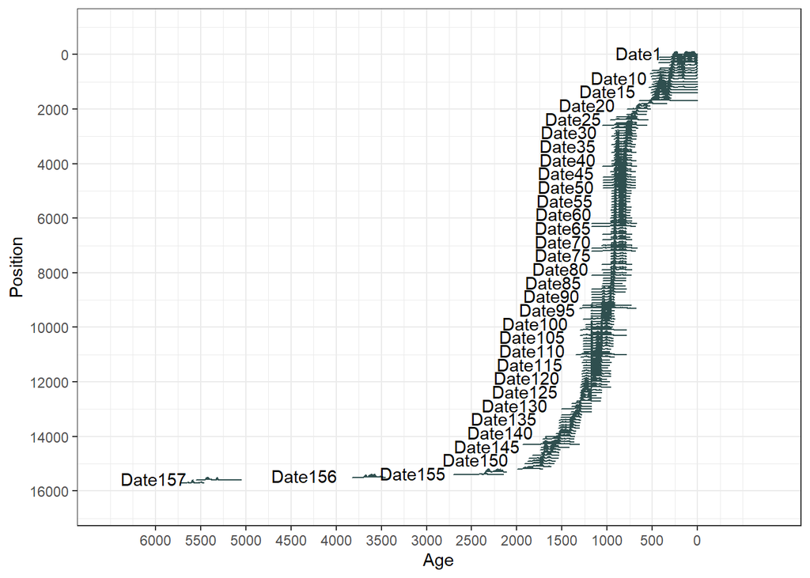

```r
setwd("D:/Desktop/Dissertation")
alldata<-read.csv("./ALL_NMC_dates.csv")
#dates<-alldata[is.na(alldata$type)==F,]
#
plot(BchronCalibrate(ages=c(sort(alldata$uncal_age,decreasing=F)),
                     ageSds=c(alldata$uncal_err),
                     positions=seq(0,15700,100),
                     calCurves=rep('intcal20',nrow(alldata))),withPositions=T)
```

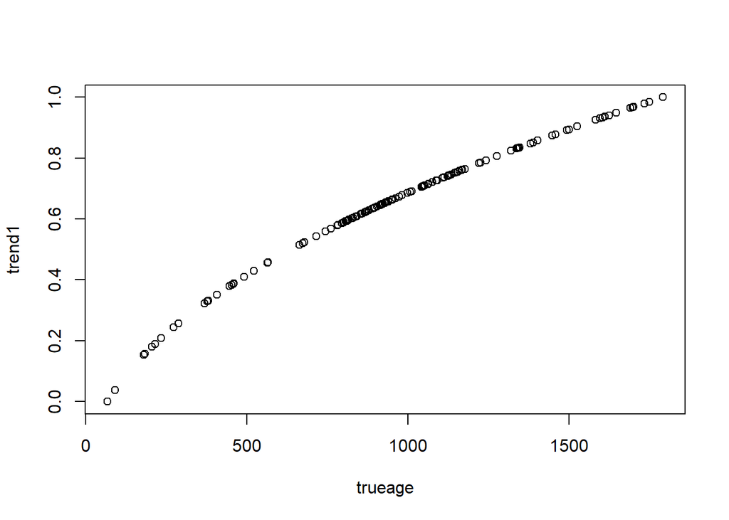

```r
#column to dump our "true" age in.
alldata$trueage<-NA

for (i in 1:nrow(alldata)){
  caldate<-calibrate(x=alldata$uncal_age[i],
                     errors=alldata$uncal_err[i],
                     calCurves='intcal20',
                     verbose=F)

  trueage<-sample(x=caldate$grid$'1'[,1],
                            1,
                            prob=caldate$grid$'1'[,2])
  alldata$trueage[i]<-trueage
}

#Next, we need to insert a trend. I am thinking 3 variables.

#order data by true date
alldata<-alldata[order(alldata$trueage),]
#crop out so its only over 2ky
alldata<-alldata[alldata$trueage<=2000,]

#now to insert our trends
alldata$trend1<-range01(sqrt(alldata$trueage))
plot(trend1~trueage,alldata)
```

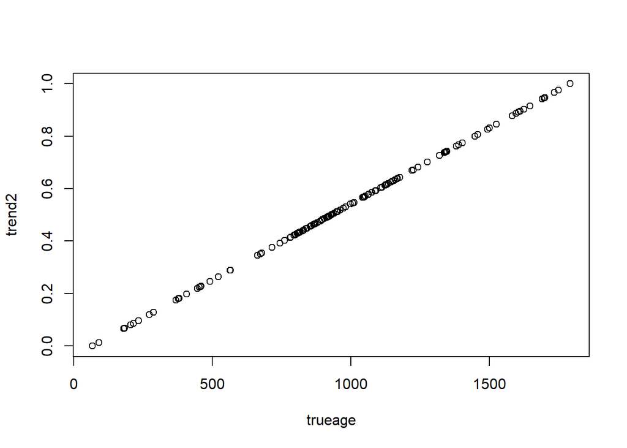

```r
alldata$trend2<-range01((alldata$trueage*2))
plot(trend2~trueage,alldata)
```

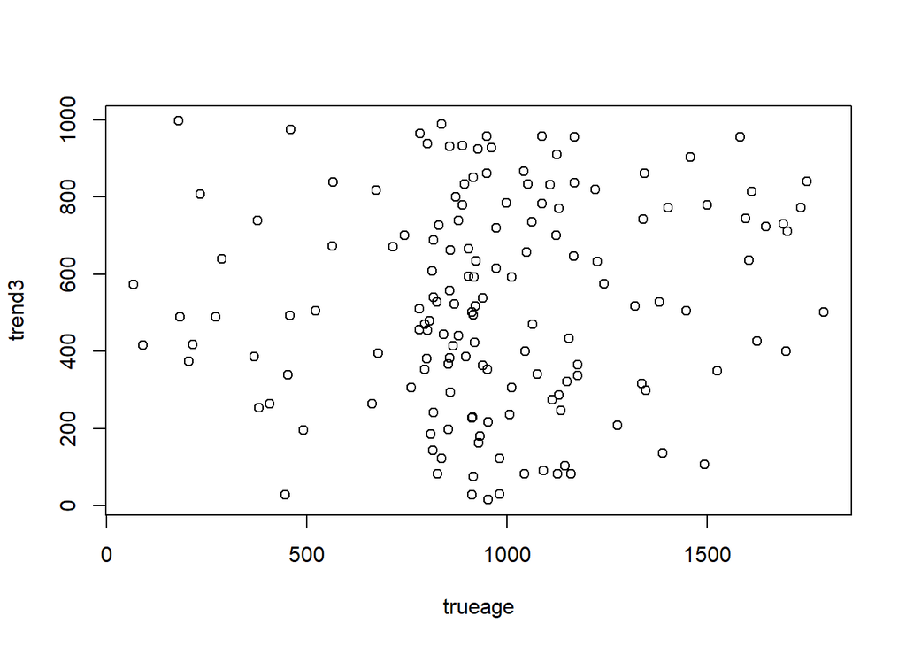

```r
alldata$trend3<-sample(1:1000,nrow(alldata),replace=T)
plot(trend3~trueage,alldata)
```

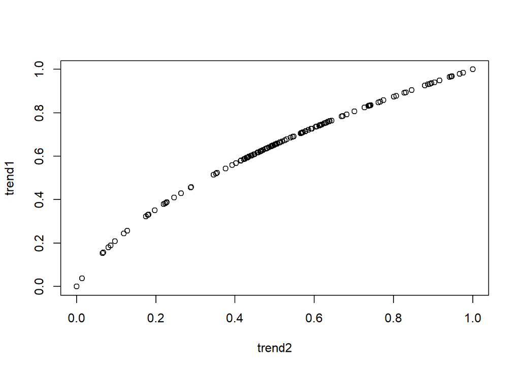

```r
#and trend 1 and trend 2 have a relationship
plot(trend1~trend2,alldata)
```

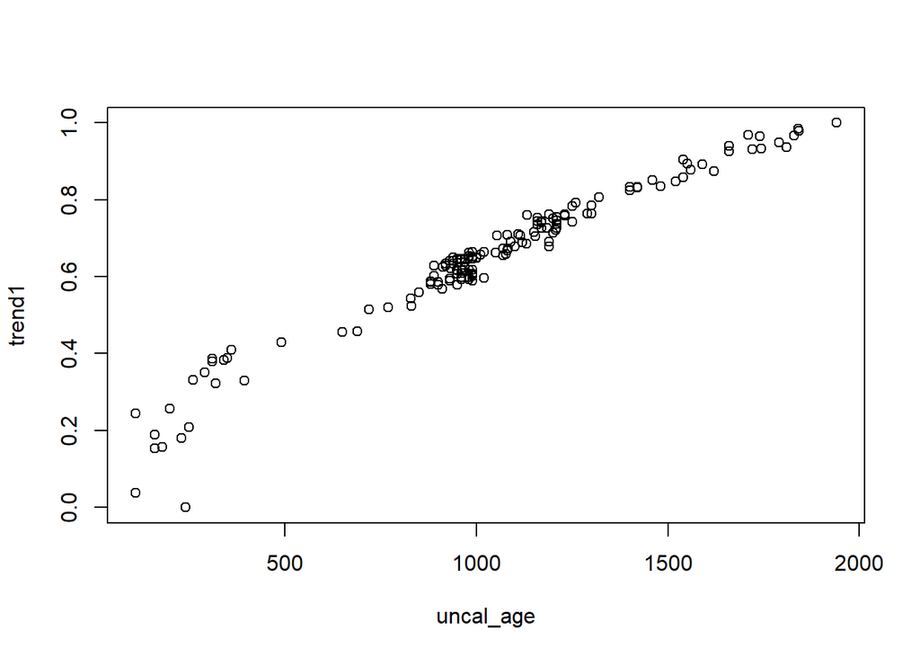

```r
#####Now to run these data as if we only have the trends and the uncal dates, like archaeological data

#The trend appears quite recognizable
plot(trend1~uncal_age,alldata)
```

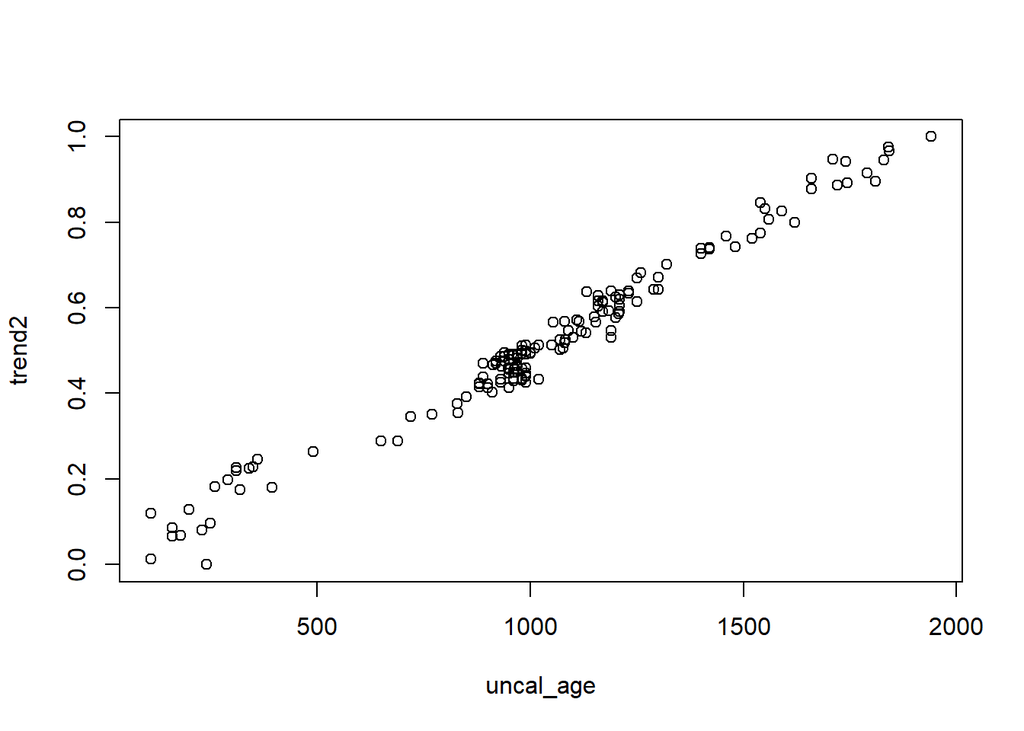

```r
plot(trend2~uncal_age,alldata)
```

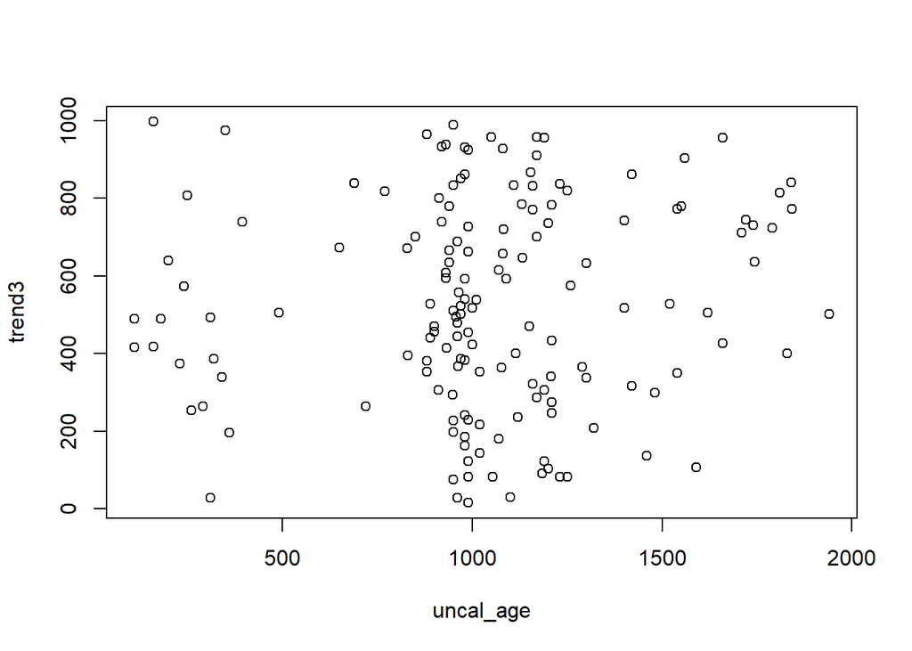

```r
plot(trend3~uncal_age,alldata)
```

##Analyses

### Weighting Values

In an attempt to incporate the calibrated radiocarbon distribution into the model, I weight the values of each observation for the trends by the probability density of each year it is represented. There is the potential issue that this will introduce biases into the data due.

```r
df<-data.frame(yearBP=1:2000,
               meantrend1=NA,
               meantrend2=NA,
               meantrend3=NA)

#Trend 1

meantrend<-data.frame(yearBP=1:2000)
for (i in 1:nrow(alldata)){
  #meangde[,1+i]<-paste("gde",i,sep="")
  dates<-calibrate(x=alldata$uncal_age[i],errors=alldata$uncal_err[i],calCurves='intcal20',verbose=F)

  x<-data.frame(yearBP=dates$grids$'1'$calBP,trend1=alldata$trend1[i]
                *dates$grids$"1"$PrDens)
  meantrend<-merge(meantrend,x,by="yearBP",all=T)

  #above i multiply the probability of the density function by gde as a weight of how likely that year is.
}

for (i in 1:nrow(meantrend)){
  test<-meantrend[i,]
  test<-t(test)
  year<-test[1,]
  test<-test[-1,]
  meany<-mean(na.omit(test))
  df[df$yearBP==year,2]<-meany
}

##Trend 2
meantrend<-data.frame(yearBP=1:2000)
for (i in 1:nrow(alldata)){
  #meangde[,1+i]<-paste("gde",i,sep="")
  dates<-calibrate(x=alldata$uncal_age[i],errors=alldata$uncal_err[i],calCurves='intcal20',verbose=F)

  x<-data.frame(yearBP=dates$grids$'1'$calBP,trend2=alldata$trend2[i]
                *dates$grids$"1"$PrDens)
  meantrend<-merge(meantrend,x,by="yearBP",all=T)

  #above i multiply the probability of the density function by gde as a weight of how likely that year is.
}

for (i in 1:nrow(meantrend)){
  test<-meantrend[i,]
  test<-t(test)
  year<-test[1,]
  test<-test[-1,]
  meany<-mean(na.omit(test))
  df[df$yearBP==year,3]<-meany
}

### Trend 3
##Trend 2
meantrend<-data.frame(yearBP=1:2000)
for (i in 1:nrow(alldata)){
  #meangde[,1+i]<-paste("gde",i,sep="")
  dates<-calibrate(x=alldata$uncal_age[i],errors=alldata$uncal_err[i],calCurves='intcal20',verbose=F)

  x<-data.frame(yearBP=dates$grids$'1'$calBP,trend3=alldata$trend3[i]
                *dates$grids$"1"$PrDens)
  meantrend<-merge(meantrend,x,by="yearBP",all=T)

  #above i multiply the probability of the density function by gde as a weight of how likely that year is.
}

for (i in 1:nrow(meantrend)){
  test<-meantrend[i,]
  test<-t(test)
  year<-test[1,]
  test<-test[-1,]
  meany<-mean(na.omit(test))
  df[df$yearBP==year,4]<-meany
}

#gamm
mod1<-gamm(meantrend1~s(meantrend2,k=2)+s(meantrend3,k=2),data=df,correlation=corAR1())
summary(mod1$gam)
```

```
##
## Family: gaussian
## Link function: identity
##
## Formula:
## meantrend1 ~ s(meantrend2, k = 2) + s(meantrend3, k = 2)
##
## Parametric coefficients:
##              Estimate Std. Error t value Pr(>|t|)
## (Intercept) 0.0022545  0.0001301   17.33   <2e-16 ***
## ---
## Signif. codes:  0 '***' 0.001 '**' 0.01 '*' 0.05 '.' 0.1 ' ' 1
##
## Approximate significance of smooth terms:
##                 edf Ref.df     F p-value
## s(meantrend2) 1.998  1.998 14742  <2e-16 ***
## s(meantrend3) 1.998  1.998  1502  <2e-16 ***
## ---
## Signif. codes:  0 '***' 0.001 '**' 0.01 '*' 0.05 '.' 0.1 ' ' 1
##
## R-sq.(adj) =  0.969
##   Scale est. = 4.998e-08  n = 1998
```

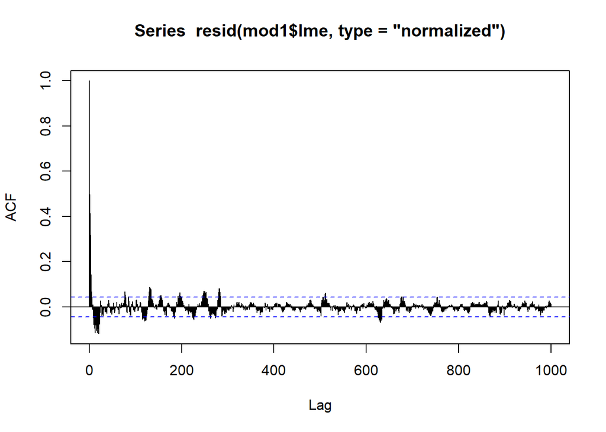

```r
acf(resid(mod1$lme,type="normalized"),lag.max=1000)
```

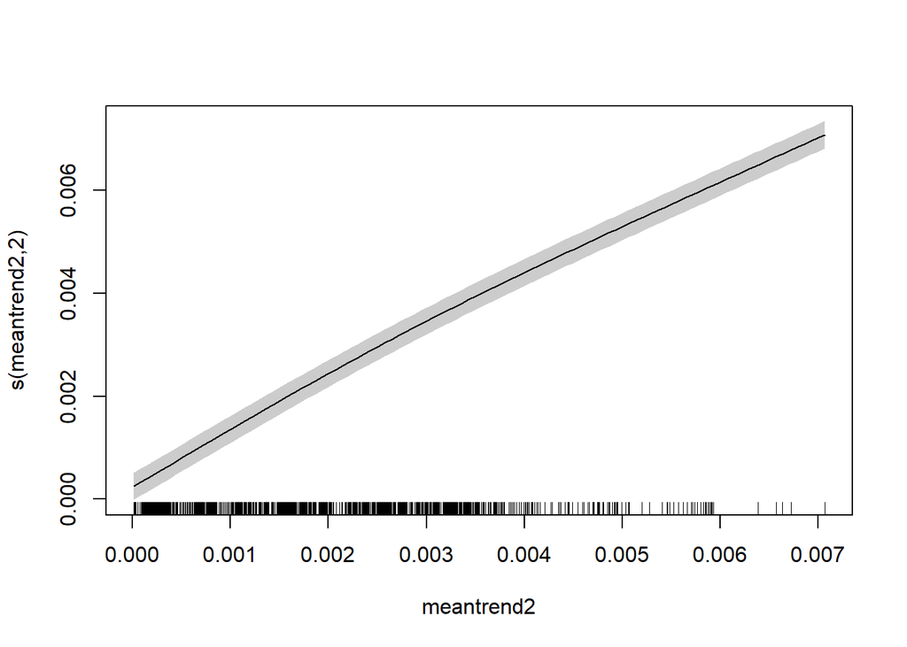

```r
plot(mod1$gam,shift=mod1$gam$coefficients[1],shade=T,select=1,seWithMean=TRUE);box()
```

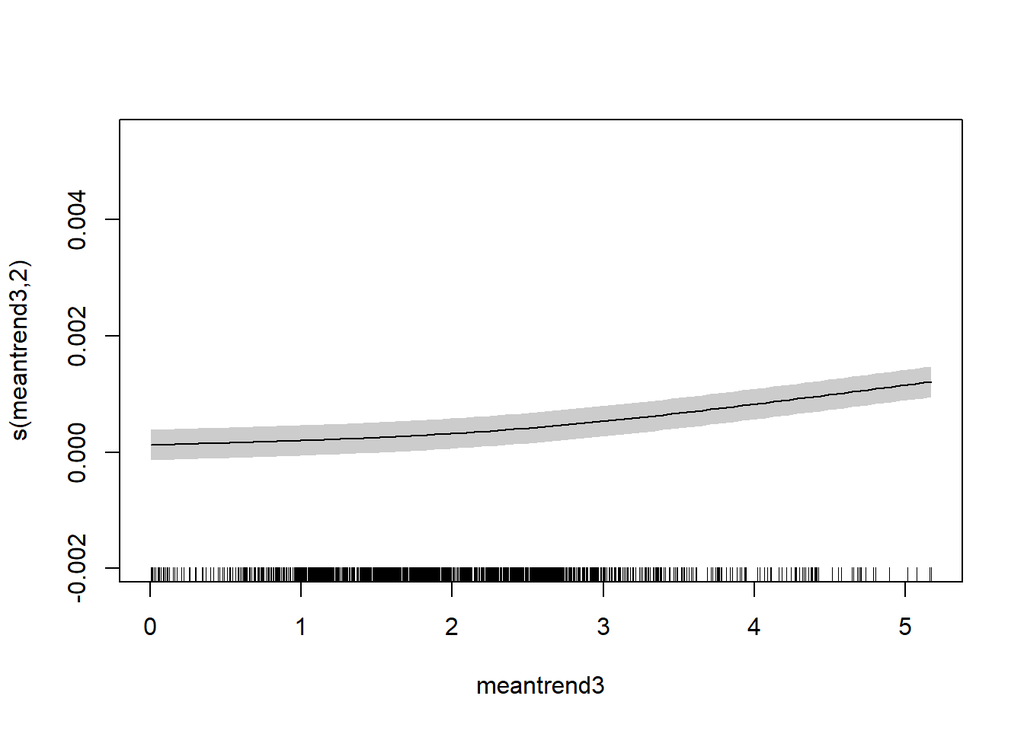

```r
plot(mod1$gam,shift=mod1$gam$coefficients[2],shade=T,select=2,seWithMean=TRUE);box()
```

### Uniform Distribution

By not weighting the values, we assume a uniform distribution across all years that have a probability density from the calibrated radiocarbon date.

```r
df<-data.frame(yearBP=1:2000,
               meantrend1=NA,
               meantrend2=NA,
               meantrend3=NA)

#Trend 1

meantrend<-data.frame(yearBP=1:2000)
for (i in 1:nrow(alldata)){
  #meangde[,1+i]<-paste("gde",i,sep="")
  dates<-calibrate(x=alldata$uncal_age[i],errors=alldata$uncal_err[i],calCurves='intcal20',verbose=F)

  x<-data.frame(yearBP=dates$grids$'1'$calBP,trend1=alldata$trend1[i])
                #*dates$grids$"1"$PrDens)
  meantrend<-merge(meantrend,x,by="yearBP",all=T)

  #above i multiply the probability of the density function by gde as a weight of how likely that year is.
}

for (i in 1:nrow(meantrend)){
  test<-meantrend[i,]
  test<-t(test)
  year<-test[1,]
  test<-test[-1,]
  meany<-mean(na.omit(test))
  df[df$yearBP==year,2]<-meany
}

##Trend 2
meantrend<-data.frame(yearBP=1:2000)
for (i in 1:nrow(alldata)){
  #meangde[,1+i]<-paste("gde",i,sep="")
  dates<-calibrate(x=alldata$uncal_age[i],errors=alldata$uncal_err[i],calCurves='intcal20',verbose=F)

  x<-data.frame(yearBP=dates$grids$'1'$calBP,trend2=alldata$trend2[i])
                #*dates$grids$"1"$PrDens)
  meantrend<-merge(meantrend,x,by="yearBP",all=T)

  #above i multiply the probability of the density function by gde as a weight of how likely that year is.
}

for (i in 1:nrow(meantrend)){
  test<-meantrend[i,]
  test<-t(test)
  year<-test[1,]
  test<-test[-1,]
  meany<-mean(na.omit(test))
  df[df$yearBP==year,3]<-meany
}

### Trend 3
##Trend 2
meantrend<-data.frame(yearBP=1:2000)
for (i in 1:nrow(alldata)){
  #meangde[,1+i]<-paste("gde",i,sep="")
  dates<-calibrate(x=alldata$uncal_age[i],errors=alldata$uncal_err[i],calCurves='intcal20',verbose=F)

  x<-data.frame(yearBP=dates$grids$'1'$calBP,trend3=alldata$trend3[i])
                #*dates$grids$"1"$PrDens)
  meantrend<-merge(meantrend,x,by="yearBP",all=T)

  #above i multiply the probability of the density function by gde as a weight of how likely that year is.
}

for (i in 1:nrow(meantrend)){
  test<-meantrend[i,]
  test<-t(test)
  year<-test[1,]
  test<-test[-1,]
  meany<-mean(na.omit(test))
  df[df$yearBP==year,4]<-meany
}

#gamm
mod1<-gamm(meantrend1~s(meantrend2,k=2)+s(meantrend3,k=2),data=df,correlation=corAR1())
summary(mod1$gam)
```

```
##
## Family: gaussian
## Link function: identity
##
## Formula:
## meantrend1 ~ s(meantrend2, k = 2) + s(meantrend3, k = 2)
##
## Parametric coefficients:
##             Estimate Std. Error t value Pr(>|t|)
## (Intercept)  0.65024    0.02353   27.64   <2e-16 ***
## ---
## Signif. codes:  0 '***' 0.001 '**' 0.01 '*' 0.05 '.' 0.1 ' ' 1
##
## Approximate significance of smooth terms:
##                 edf Ref.df        F  p-value
## s(meantrend2) 2.000  2.000 30411.00  < 2e-16 ***
## s(meantrend3) 1.976  1.976    38.15 6.41e-14 ***
## ---
## Signif. codes:  0 '***' 0.001 '**' 0.01 '*' 0.05 '.' 0.1 ' ' 1
##
## R-sq.(adj) =  0.991
##   Scale est. = 0.00071564  n = 1998
```

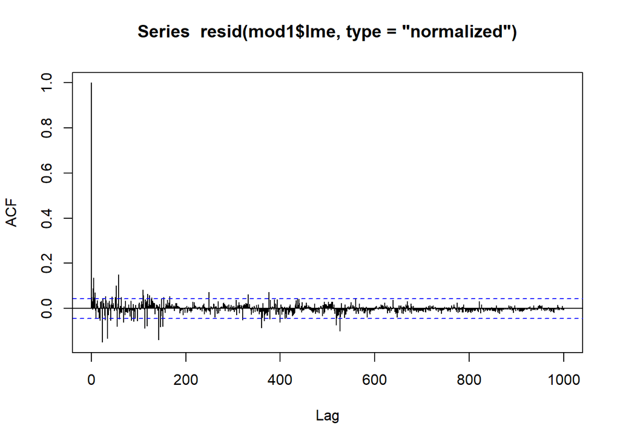

```r
acf(resid(mod1$lme,type="normalized"),lag.max=1000)
```

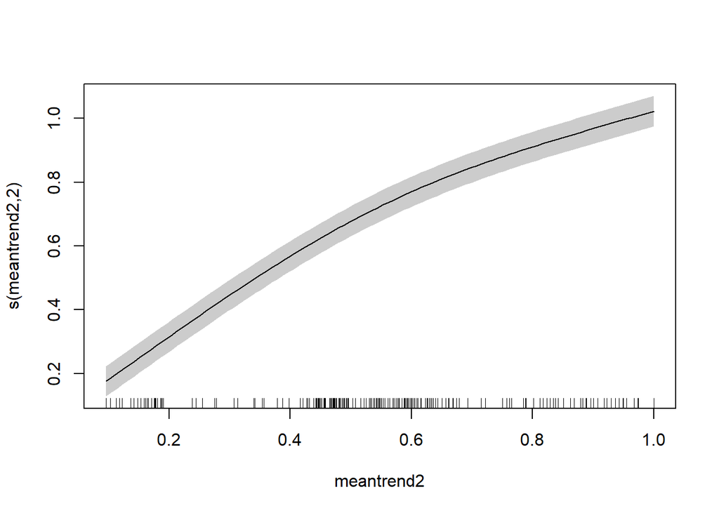

```r
plot(mod1$gam,shift=mod1$gam$coefficients[1],shade=T,select=1,seWithMean=TRUE);box()
```

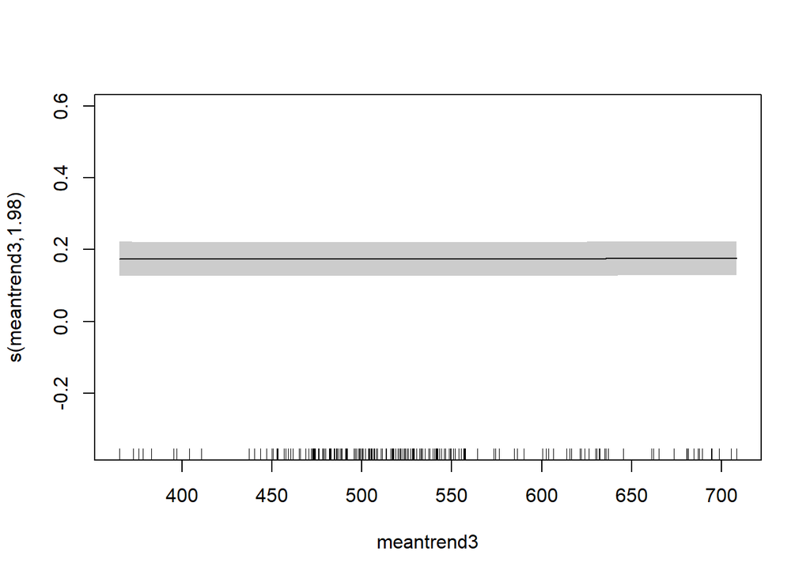

```r
plot(mod1$gam,shift=mod1$gam$coefficients[2],shade=T,select=2,seWithMean=TRUE);box()
```